# 五王之战分析 - 冰与火之歌

## 简介

五王之战（War of the Five Kings）是著名严肃奇幻小说《冰与火之歌》中的著名内战。这是一场规模空前、波及七大王国的内乱。顾名思义，前后共有五人在战争中称王：乔佛里、史坦尼斯、蓝礼均声称自己是铁王座的合法继承人。除此之外，罗柏·史塔克被北境众封臣推选为北境之王，巴隆·葛雷乔伊亦再度掀起独立大旗，欲摆脱铁王座的统治，自称为铁群岛之王。

本数据集(battles.csv)包含了五王之战期间的战争，它是所有战斗的大集合。该数据是Kaggle中[Game of Thrones](https://www.kaggle.com/mylesoneill/game-of-thrones)的一部分。

数据中的变量含义解释：

```
name: 战争的名称，字符变量。
year: 战争发生的年份，数值变量。
battle_number: 本数据中的unique id，对应每一场独立的战役，数值变量。
attacker_king: 攻击方的国王，"/"表示了国王的更换。例如："Joffrey/Tommen Baratheon"意味着Tomen Baratheon继承了Joffrey的王位，分类变量。
defender_king: 防守方的国王，分类变量。
attacker_1: 攻击方将领，字符变量。
attacker_2: 攻击方将领，字符变量。
attacker_3: 攻击方将领，字符变量。
attacker_4: 攻击方将领，字符变量。
defender_1: 防守方将领，字符变量。
defender_2: 防守方将领，字符变量。
defender_3: 防守方将领，字符变量。
defender_4: 防守方将领，字符变量。
attacker_outcome: 从攻击方角度来看的战争结果，分别有：win, loss, draw，分类变量。
battle_type: 战争的类别。pitched_battle: 双方军队在一个地点相遇并战斗，这也是最基本的战争类别；ambush: 以隐身或诡计为主要攻击手段的战争；siege: 阵地战；razing: 对未设防位置的攻击。分类变量。
major_death: 是否有重要人物的死亡，二进制变量。
major_capture: 是否有重要人物的被捕，二进制变量。
attacker_size: 攻击方力量的大小，并未对骑兵、步兵等士兵种类有所区分，数值变量。
defender_size: 防守方力量的大小，并未对骑兵、步兵等士兵种类有所区分，数值变量。
attacker_commander: 攻击方的主要指挥官。指挥官的名字中并没有包含头衔，不同的指挥官名字用逗号隔开，字符变量。
defender_commander: 防守方的主要指挥官。指挥官的名字中并没有包含头衔，不同的指挥官名字用逗号隔开，字符变量。
summer: 战争是否发生于夏天，二进制变量。
location: 战争发生的地点，字符变量。
region: 战争发生的地域，包括：Beyond the Wall, The North, The Iron Islands, The Riverlands, The Vale of Arryn, The Westerlands, The Crownlands, The Reach, The Stormlands, Dorne，分类变量。
note: 注释，字符变量。
```

## 项目完成指南

本项目中的数据分析流程已经给出，但代码将完全由你自己进行书写，如果你无法完成本项目，说明你目前的能力并不足以完成 数据分析(进阶)纳米学位，建议先进行 数据分析（入门）纳米学位的学习，掌握进阶课程的先修知识。

对于数据分析过程的记录也是数据分析报告的一个重要部分，你可以自己在需要的位置插入Markdown cell，记录你在数据分析中的关键步骤和推理过程。比如：数据有什么样的特点，统计数据的含义是什么，你从可视化中可以得出什么结论，下一步分析是什么，为什么执行这种分析。如果你无法做到这一点，你也无法通过本项目。

> **小贴士**: 像这样的引用部分旨在为学员提供实用指导，帮助学员了解并使用 Jupyter notebook

## 提出问题

在此项目中，你将以一名数据分析师的身份执行数据的探索性分析。你将了解数据分析过程的基本流程。在你分析数据之前，请先思考几个你需要理解的关于这些战斗的问题，例如，哪一个区域发生了最多的战争？哪一个国王获得了最多的胜利？战争的胜利与否受那些关键因素的影响？

**问题**：请写下你感兴趣的问题，请确保这些问题能够由现有的数据进行回答。 （为了确保学习的效果，请确保你的数据分析报告中能够包含2幅可视化和1个相关性分析。）

### 问题：哪一个区域发生了最多的战争（热点区域）。

在提出了问题之后，我们将开始导入数据，并对数据进行探索性分析，来回答上面提出的问题。

> **小贴士**: 双击上框，文本就会发生变化，所有格式都会被清除，以便你编辑该文本块。该文本块是用 [Markdown](http://daringfireball.net/projects/markdown/syntax)编写的，该语言使用纯文本语法，能用页眉、链接、斜体等来规范文本格式。在纳米学位课程中，你也会用到 Markdown。编辑后，可使用 **Shift** + **Enter** 或 **Shift** + **Return** 运行上该框，使其呈现出编辑好的文本格式。

## 数据评估和清理

> **小贴士**: 运行代码框的方法与编辑上方的 Markdown 框的格式类似，你只需点击代码框，按下键盘快捷键 **Shift** + **Enter** 或 **Shift** + **Return** ，或者你也可先选择代码框，然后点击工具栏的 **运行** 按钮来运行代码。运行代码框时，相应单元左侧的信息会出现星号，即 `In [*]:`，若代码执行完毕，星号则会变为某个数字，如 `In [1]`。如果代码运行后有输出结果，输出将会以 `Out [1]:` 的形式出现，其中的数字将与 "In" 中的数字相对应。

```python
# TO DO: load pacakges
import pandas as pd
from pandas import Series,DataFrame
```

```python
# TO DO: load the dataset
data=pd.read_csv('battles.csv')
```

```python
# TO DO: check the dataset general info
data.keys()
```

```
Index(['name', 'year', 'battle_number', 'attacker_king', 'defender_king',
       'attacker_1', 'attacker_2', 'attacker_3', 'attacker_4', 'defender_1',
       'defender_2', 'defender_3', 'defender_4', 'attacker_outcome',
       'battle_type', 'major_death', 'major_capture', 'attacker_size',
       'defender_size', 'attacker_commander', 'defender_commander', 'summer',
       'location', 'region', 'note'],
      dtype='object')
```

```python
data[data.isnull().values==True]
```

[output not shown]

300 rows × 25 columns

```python
#使用'year','region','location','battle_number'进行分析
data[['year','region','location','battle_number']]
```

|  | year | region | location | battle_number |
| --- | --- | --- | --- | --- |
| 0 | 298 | The Westerlands | Golden Tooth | 1 |
| 1 | 298 | The Riverlands | Mummer's Ford | 2 |
| 2 | 298 | The Riverlands | Riverrun | 3 |
| 3 | 298 | The Riverlands | Green Fork | 4 |
| 4 | 298 | The Riverlands | Whispering Wood | 5 |
| 5 | 298 | The Riverlands | Riverrun | 6 |
| 6 | 298 | The Riverlands | Darry | 7 |
| 7 | 299 | The North | Moat Cailin | 8 |
| 8 | 299 | The North | Deepwood Motte | 9 |
| 9 | 299 | The North | Stony Shore | 10 |
| 10 | 299 | The North | Torrhen's Square | 11 |
| 11 | 299 | The North | Winterfell | 12 |
| 12 | 299 | The North | Torrhen's Square | 13 |
| 13 | 299 | The North | Winterfell | 14 |
| 14 | 299 | The Westerlands | Oxcross | 15 |
| 15 | 299 | The Stormlands | Storm's End | 16 |
| 16 | 299 | The Riverlands | Red Fork | 17 |
| 17 | 299 | The Riverlands | Harrenhal | 18 |
| 18 | 299 | The Westerlands | Crag | 19 |
| 19 | 299 | The Crownlands | King's Landing | 20 |
| 20 | 299 | The Riverlands | Darry | 21 |
| 21 | 299 | The Crownlands | Duskendale | 22 |
| 22 | 299 | The Riverlands | NaN | 23 |
| 23 | 299 | The Riverlands | Ruby Ford | 24 |
| 24 | 299 | The Riverlands | Harrenhal | 25 |
| 25 | 299 | The Riverlands | The Twins | 26 |
| 26 | 299 | The Riverlands | Seagard | 27 |
| 27 | 300 | Beyond the Wall | Castle Black | 28 |
| 28 | 300 | The North | Moat Cailin | 29 |
| 29 | 300 | The Riverlands | Saltpans | 30 |
| 30 | 300 | The North | Deepwood Motte | 31 |
| 31 | 300 | The Reach | Shield Islands | 32 |
| 32 | 300 | The Reach | Ryamsport, Vinetown, Starfish Harbor | 33 |
| 33 | 300 | The Stormlands | Storm's End | 34 |
| 34 | 300 | The Stormlands | Dragonstone | 35 |
| 35 | 300 | The Riverlands | Riverrun | 36 |
| 36 | 300 | The Riverlands | Raventree | 37 |
| 37 | 300 | The North | Winterfell | 38 |

```python
# To DO ：选取数据列进行计算
data1=data[['year','region','location']]
```

```python
data1[data1.isnull().values==True]
```

|  | year | region | location |
| --- | --- | --- | --- |
| 22 | 299 | The Riverlands | NaN |

```python
# TO DO: clean the data (optional: only there are problems)
data1=data1.dropna(subset=['location'])
```

```python
data1[data1.isnull().values==True]
```

|  | year | region | location |
| --- | --- | --- | --- |

```python
data1.count()
```

```
year        37
region      37
location    37
dtype: int64
```

## 数据探索分析

```python
# In exploratory data analysis, please make sure of using statistics and visualizations
#### 共38场战争但是
data1.groupby(['year','region']).count().unstack()
```

| region year | location Beyond the Wall | location The Crownlands | location The North | location The Reach | location The Riverlands | location The Stormlands | location The Westerlands |
| --- | --- | --- | --- | --- | --- | --- | --- |
| 298 | NaN | NaN | NaN | NaN | 6.0 | NaN | 1.0 |
| 299 | NaN | 2.0 | 7.0 | NaN | 7.0 | 1.0 | 2.0 |
| 300 | 1.0 | NaN | 3.0 | 2.0 | 3.0 | 2.0 | NaN |

```python
data12=data1.groupby(['year','region']).year.count().unstack()
data12
```

| region year | Beyond the Wall | The Crownlands | The North | The Reach | The Riverlands | The Stormlands | The Westerlands |
| --- | --- | --- | --- | --- | --- | --- | --- |
| 298 | NaN | NaN | NaN | NaN | 6.0 | NaN | 1.0 |
| 299 | NaN | 2.0 | 7.0 | NaN | 7.0 | 1.0 | 2.0 |
| 300 | 1.0 | NaN | 3.0 | 2.0 | 3.0 | 2.0 | NaN |

```python
data1[['region','location']].groupby('region').count()
```

| region | location |
| --- | --- |
| Beyond the Wall | 1 |
| The Crownlands | 2 |
| The North | 10 |
| The Reach | 2 |
| The Riverlands | 16 |
| The Stormlands | 3 |
| The Westerlands | 3 |

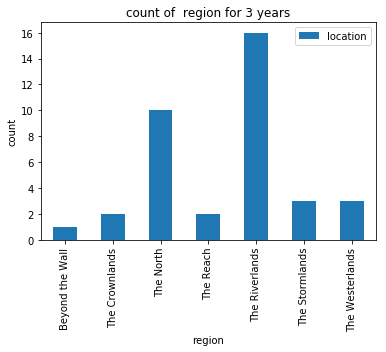

```python
### count of  region for 3 years
%matplotlib inline
import matplotlib.pyplot as plt
data1[['region','location']].groupby('region').count().plot(kind='bar',title="count of  region for 3 years")
plt.ylabel('count')
plt.show()
```

#### 每个region三年总共发生战争的次数安照region进行统计，同时可知“The Riverlands”发生的战争最多

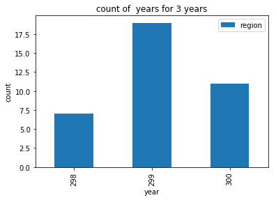

```python
### count of  years for 3 years
%matplotlib inline
import matplotlib.pyplot as plt
data1[['region','year']].groupby('year').count().plot(kind='bar',title="count of  years for 3 years")
plt.ylabel('count')
plt.show()
```

```python
data1.groupby(['location','region']).count()
```

| location | region | year |
| --- | --- | --- |
| Castle Black | Beyond the Wall | 1 |
| Crag | The Westerlands | 1 |
| Darry | The Riverlands | 2 |
| Deepwood Motte | The North | 2 |
| Dragonstone | The Stormlands | 1 |
| Duskendale | The Crownlands | 1 |
| Golden Tooth | The Westerlands | 1 |
| Green Fork | The Riverlands | 1 |
| Harrenhal | The Riverlands | 2 |
| King's Landing | The Crownlands | 1 |
| Moat Cailin | The North | 2 |
| Mummer's Ford | The Riverlands | 1 |
| Oxcross | The Westerlands | 1 |
| Raventree | The Riverlands | 1 |
| Red Fork | The Riverlands | 1 |
| Riverrun | The Riverlands | 3 |
| Ruby Ford | The Riverlands | 1 |
| Ryamsport, Vinetown, Starfish Harbor | The Reach | 1 |
| Saltpans | The Riverlands | 1 |
| Seagard | The Riverlands | 1 |
| Shield Islands | The Reach | 1 |
| Stony Shore | The North | 1 |
| Storm's End | The Stormlands | 2 |
| The Twins | The Riverlands | 1 |
| Torrhen's Square | The North | 2 |
| Whispering Wood | The Riverlands | 1 |
| Winterfell | The North | 3 |

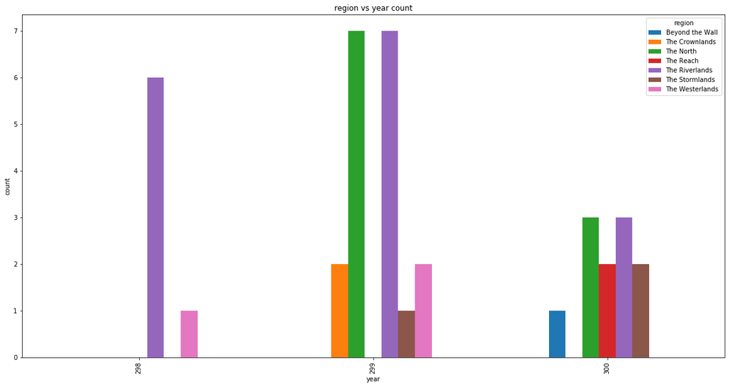

```python
###region vs year
%matplotlib inline
import matplotlib.pyplot as plt
data12.plot(kind='bar',figsize=(20,10),title="region vs year count")
plt.ylabel('count')
plt.show()
```

#### 通过对于每年的相关地区中发生的战争次数进行统计，发现战争发生在The RiverLnads最多且年年都有战争爆发，同时THE north在299~300年间也是频繁发生战争。

在数据的探索性分析中，请确保你对数据分析中的关键步骤和推理过程进行了记录。你可以自己插入code cell和markdown cell来组织你的报告。

## 得出结论

**问题**：上面的分析能够回答你提出的问题？通过这些分析你能够得出哪些结论？

#### 从上面的分析中发现在299~300年之间“The RiverLnads”几乎年年都有战争爆发，可知这个地方可能是战略的要地，同时这个region发生战争的次数最多，该地方的遭受战争的损失可能最大（平民损失）！

## 反思

恭喜你完成了此项目！这只是数据分析过程的一个样本：从生成问题、整理数据、探索数据到得出结论。在数据分析(进阶)纳米学位中，你将会学到更多高级的数据分析方法和技术，如果你感兴趣的话，我们鼓励你继续学习后续的课程，掌握更多的数据分析的高级技能！

> 若想与他人分享我们的分析结果，除了向他们提供 jupyter Notebook (.ipynb) 文件的副本外，我们还可以将 Notebook 输出导出为一种甚至那些未安装 Python 的人都能打开的形式。从左上方的“文件”菜单，前往“下载为”子菜单。然后你可以选择一个可以更普遍查看的格式，例如 HTML (.html) 。你可能需要额外软件包或软件来执行这些导出。